# R Notebook

The ggplot2 theme system allows you to exercise fine control over the non-data elements of your plot.

The theming system is composed of four main components:

Theme elements specify the non-data elements that you can control. For example, the plot.title element controls the appearance of the plot title; axis.ticks.x, the ticks on the x axis; legend.key.height, the height of the keys in the legend.

Each element is associated with an element function, which describes the visual properties of the element. For example, element_text() sets the font size, colour and face of text elements like plot.title.

The theme() function which allows you to override the default theme elements by calling element functions, like theme(plot.title = element_text(colour = “red”)).

Complete themes, like theme_grey() set all of the theme elements to values designed to work together harmoniously.

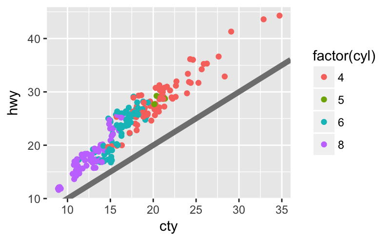

```r
base <- ggplot(mpg, aes(cty, hwy, color = factor(cyl))) +
  geom_jitter() +
  geom_abline(colour = "grey50", size = 2)
base
```

# Labelling

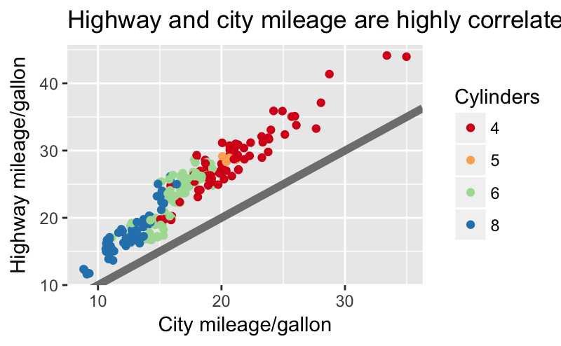

```r
labelled <- base +
  labs(
    x = "City mileage/gallon",
    y = "Highway mileage/gallon",
    colour = "Cylinders",
    title = "Highway and city mileage are highly correlated"
  ) +
  scale_colour_brewer(type = "seq", palette = "Spectral")
labelled
```

# Style

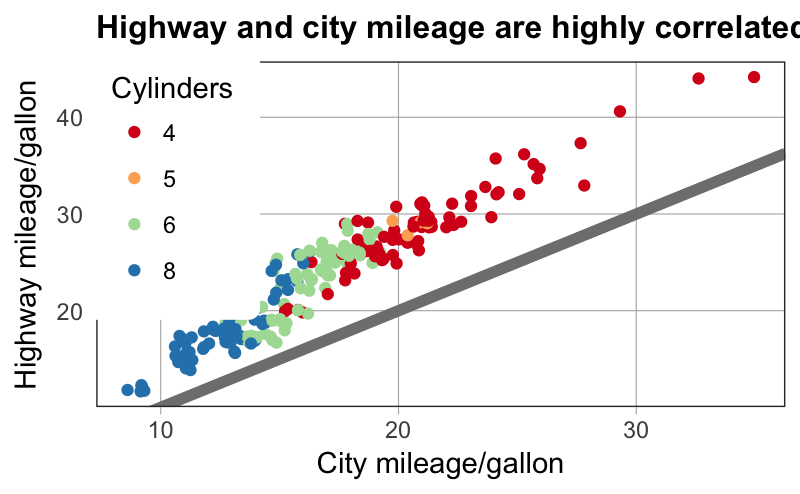

```r
styled <- labelled +
  theme_bw() +
  theme(
    plot.title = element_text(face = "bold", size = 12),
    legend.background = element_rect(fill = "white", size = 4, colour = "white"),
    legend.justification = c(0, 1),
    legend.position = c(0, 1),
    axis.ticks = element_line(colour = "grey70", size = 0.2),
    panel.grid.major = element_line(colour = "grey70", size = 0.2),
    panel.grid.minor = element_blank()
  )
styled
```

# Complete Themes

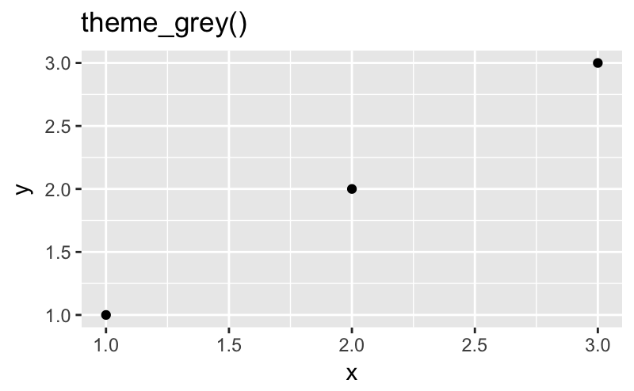

```r
df <- data.frame(x = 1:3, y = 1:3)
base <- ggplot(df, aes(x, y)) + geom_point()
base + theme_grey() + ggtitle("theme_grey()")
```

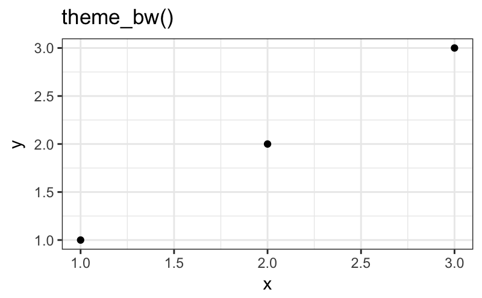

```r
base + theme_bw() + ggtitle("theme_bw()")
```

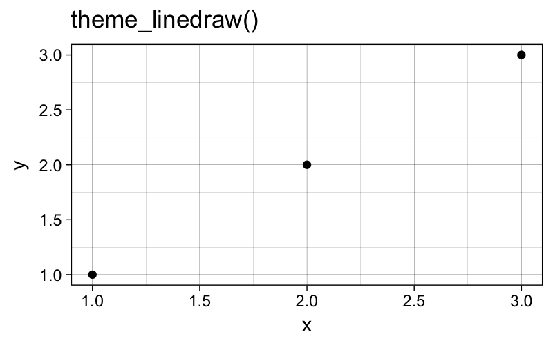

```r
base + theme_linedraw() + ggtitle("theme_linedraw()")
```

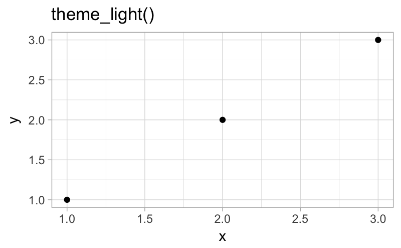

```r
base + theme_light() + ggtitle("theme_light()")
```

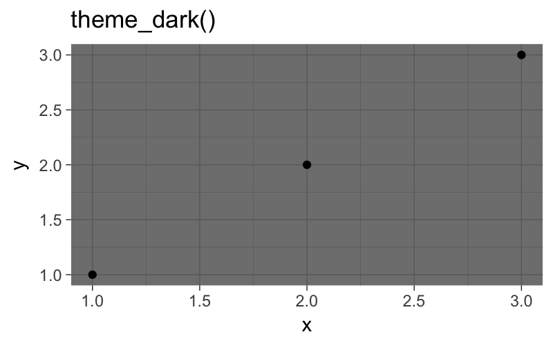

```r
base + theme_dark() + ggtitle("theme_dark()")
```

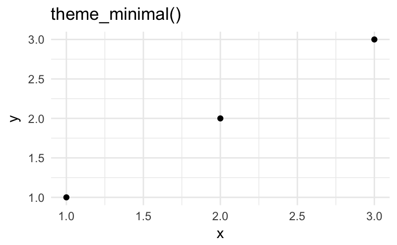

```r
base + theme_minimal()  + ggtitle("theme_minimal()")
```

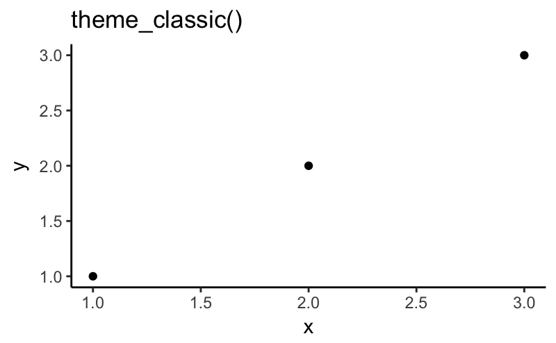

```r
base + theme_classic() + ggtitle("theme_classic()")
```

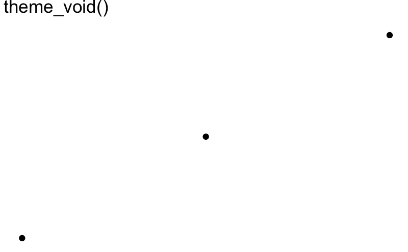

```r
base + theme_void() + ggtitle("theme_void()")
```

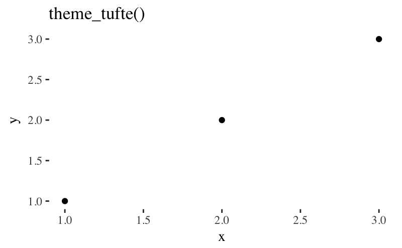

```r
library(ggthemes)
base + theme_tufte() + ggtitle("theme_tufte()")
```

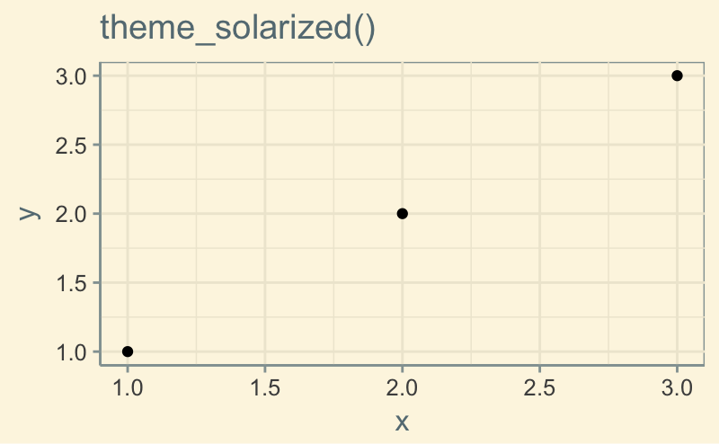

```r
base + theme_solarized() + ggtitle("theme_solarized()")
```

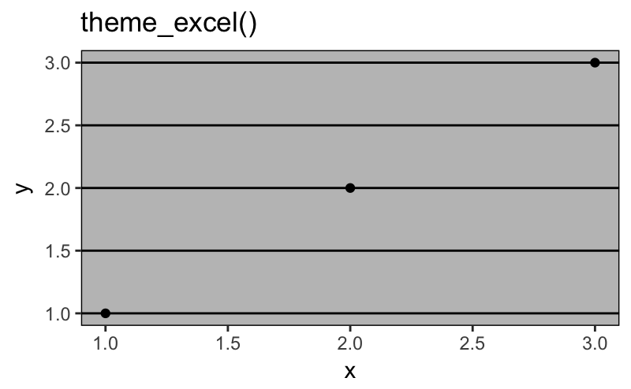

```r
base + theme_excel() + ggtitle("theme_excel()") # ;)
```

### Exercises

Exercises

Try out all the themes in ggthemes. Which do you like the best?

What aspects of the default theme do you like? What don’t you like? What would you change?

Look at the plots in your favourite scientific journal. What theme do they most resemble? What are the main differences?

# Labels and Headings

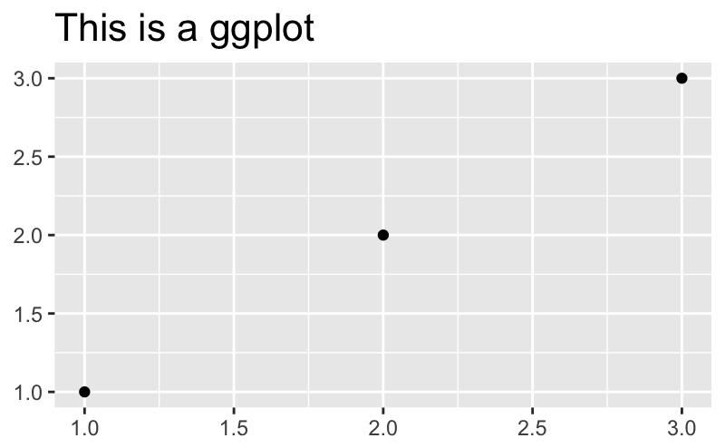

```r
base_t <- base + labs(title = "This is a ggplot") + xlab(NULL) + ylab(NULL)
base_t + theme(plot.title = element_text(size = 16))
```

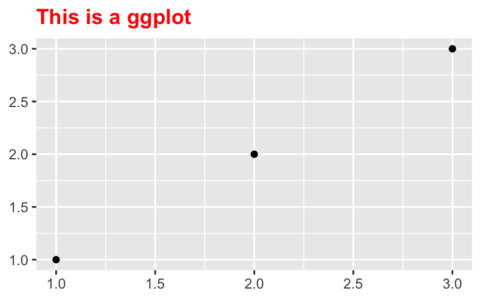

```r
base_t + theme(plot.title = element_text(face = "bold", colour = "red"))
```

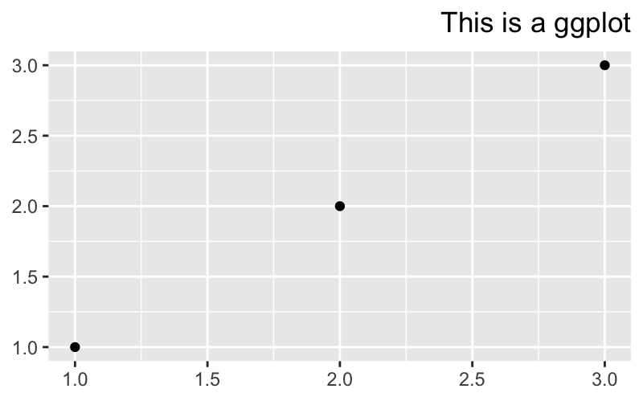

```r
base_t + theme(plot.title = element_text(hjust = 1))
```

# Margins

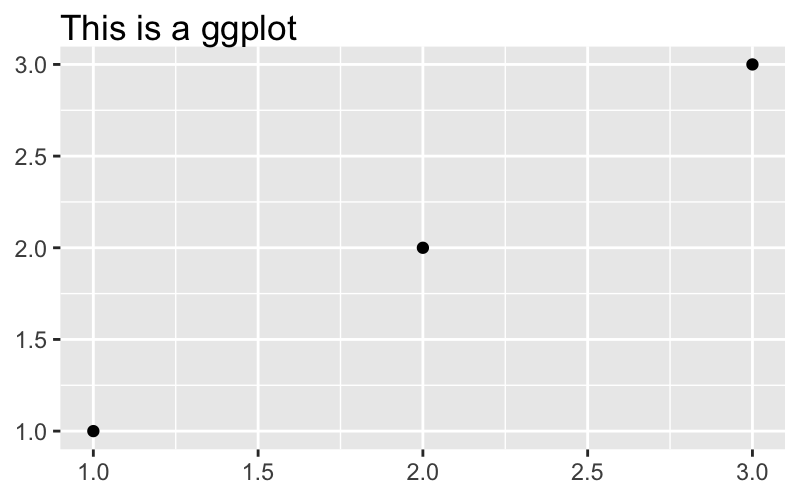

```r
base_t + theme(plot.title = element_text(margin = margin()))
```

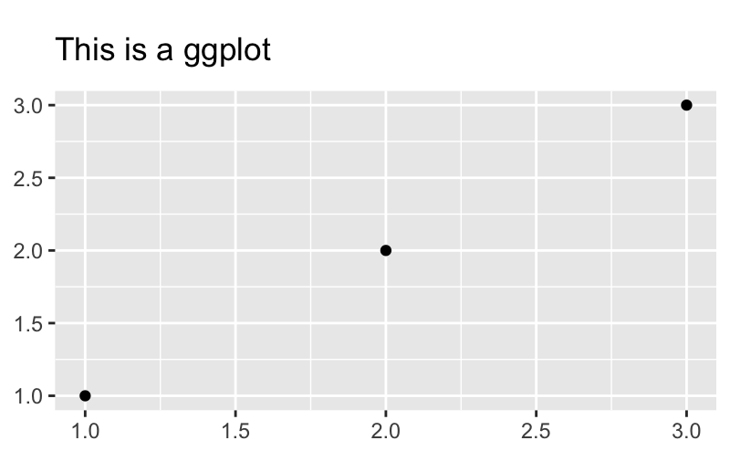

```r
base_t + theme(plot.title = element_text(margin = margin(t = 10, b = 10)))
```

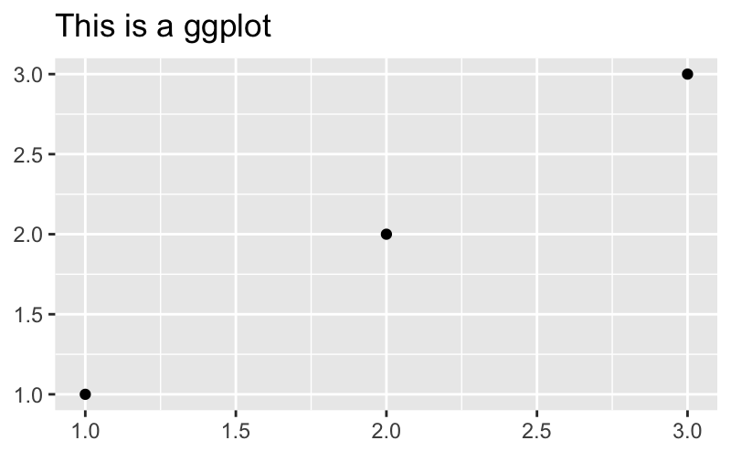

```r
base_t + theme(axis.title.y = element_text(margin = margin(r = 10)))
```

# Customise the grid

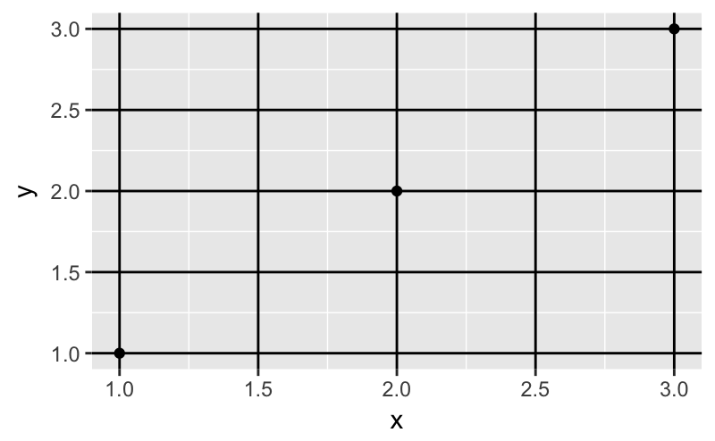

```r
base + theme(panel.grid.major = element_line(colour = "black"))
```

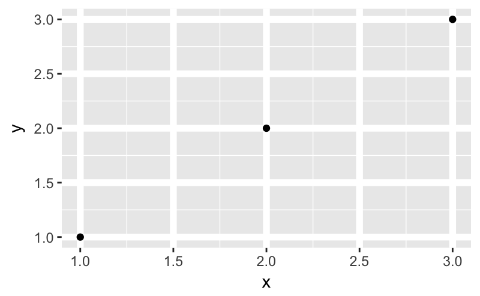

```r
base + theme(panel.grid.major = element_line(size = 2))
```

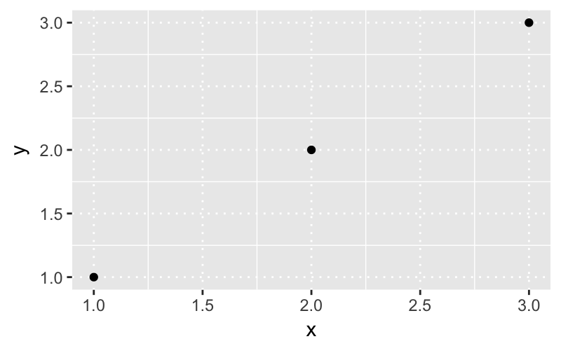

```r
base + theme(panel.grid.major = element_line(linetype = "dotted"))
```

# Background fill

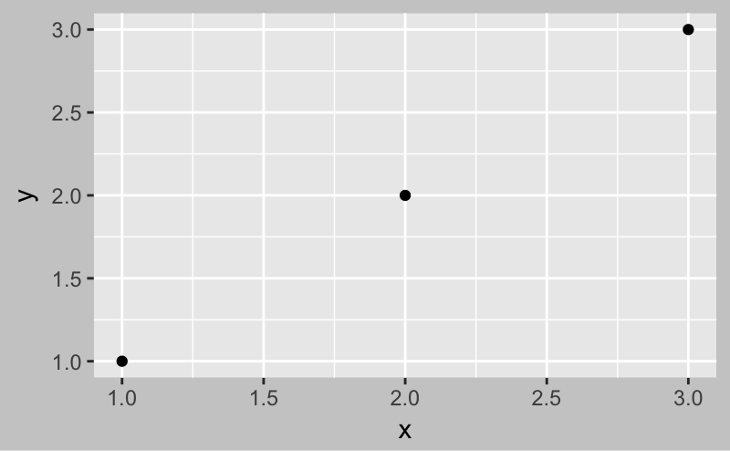

```r
base + theme(plot.background = element_rect(fill = "grey80", colour = NA))
```

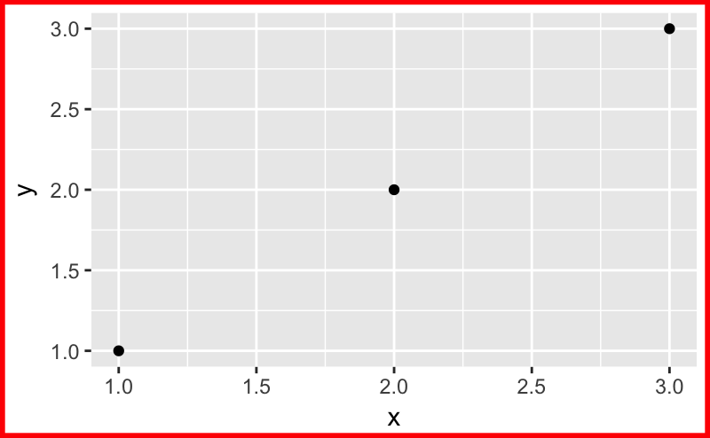

```r
base + theme(plot.background = element_rect(colour = "red", size = 2))
```

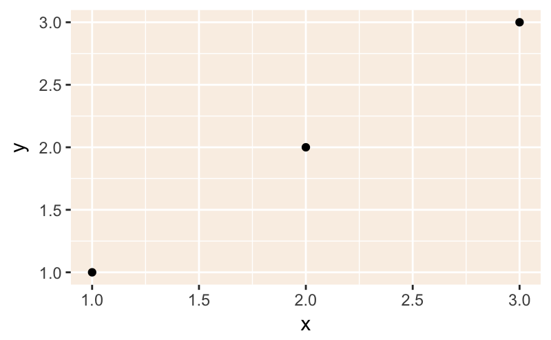

```r
base + theme(panel.background = element_rect(fill = "linen"))
```

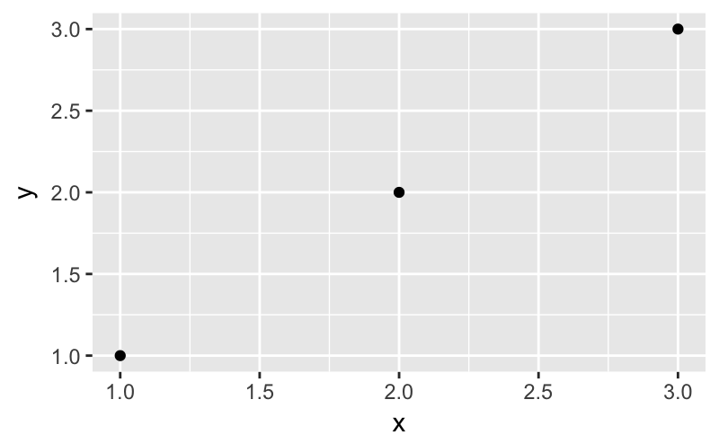

```r
base
```

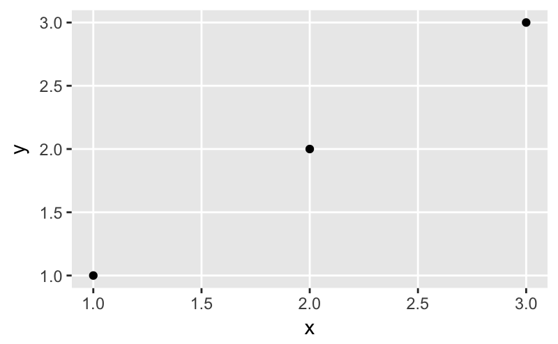

```r
last_plot() + theme(panel.grid.minor = element_blank())
```

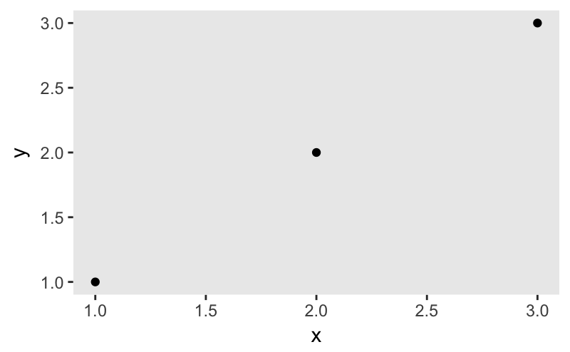

```r
last_plot() + theme(panel.grid.major = element_blank())
```